# DisPerSE_Experiments

```python
import numpy as np
import matplotlib.pyplot as plt
import matplotlib.colors as colors
import matplotlib.patches as patches
import astropy.io.fits as fits
from astropy import units as u
from collections import defaultdict
from matplotlib.patches import  ConnectionPatch
```

```python
import DPConCFil
from DPConCFil.Clump_Class import *
from DPConCFil.Filament_Class import *
import DPConCFil.Plot_and_Save_Funs as Plot_and_Save_Funs
import DPConCFil.Profile_Funs as Profile_Funs
```

## The reference of the Example data

'Example_Filaments_13CO_1.fits' is the $^{13}CO$ ($J = 1-0$) emission line of the Milky Way Imaging Scroll Painting (MWISP) within $17.7^{\circ} \leq l \leq 18.5^{\circ}$, $0^{\circ} \leq b \leq 0.8^{\circ}$ and 5 km s$^{-1}$ $\leq v \leq$ 30 km s$^{-1}$.

MWISP project is a multi-line survey in $^{12}CO$/$^{13}CO$/$C^{18}O$ along the northern galactic plane with PMO-13.7m telescope.

```python
file_example = 'Example_Filaments_13CO_1'
file_name = "../Example_Files/Data/{}.fits".format(file_example)
```

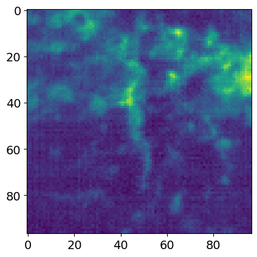

```python
real_data = fits.getdata(file_name)
plt.imshow(real_data.sum(0))
plt.show()
```

## Calculate the clump information

The parameters of FacetClumps. Please see the introduction of [FacetClumps](https://github.com/JiangYuTS/FacetClumps/blob/master/Examples/Examples_Files_FacetClumps.ipynb) for more details.

```python
SWindow = 3 # [3,5,7]
KBins = 35 # [10,...,60]
FwhmBeam = 2
VeloRes = 2
SRecursionLBV = [9, 4] # [(2+FwhmBeam)**2,3+VeloRes]

header = fits.getheader(file_name)
RMS = header['RMS']
Threshold = 5 * RMS

parameters_FacetClumps = [RMS, Threshold, SWindow, KBins, FwhmBeam, VeloRes, SRecursionLBV]
```

Construct clump objects. These file names are necessary parameters.

**file_name**: File name.

**mask_name**: Mask name, the file use to store the region information or store the region information.

**outcat_name**: The file used to store clump table in pixel coordinate system.

**outcat_wcs_name**: The file used to store clump table in WCS coordinate system.

```python
mask_name = 'Example_Files/Clump/mask_{}.fits'.format(file_example)
outcat_name = 'Example_Files/Clump/outcat_{}.csv'.format(file_example)
outcat_wcs_name = 'Example_Files/Clump/outcat_wcs_{}.csv'.format(file_example)
```

```python
clumpsObj = ClumpInfor(file_name,mask_name,outcat_name,outcat_wcs_name)
```

### Calculate the clump information from FacetClumps.

In this case, the parameters of FacetClumps is essential. More clump detection algorithms can also be added to this process.

The angle of the clumps detected by FacetClumps is obtained by diagonalizing the moment of inertia matrix, please the article of [FacetClumps](https://iopscience.iop.org/article/10.3847/1538-4365/acda89) for more details. Performing a two-dimensional single Gaussian fitting on the velocity integrated map of a clump can provide more accurate position and direction information of the clump in spatial direction.

When 'fit_flag=True', it indicates that the fitting will be used. This will benefit the performance of DPConFil.

```python
clumpsObj.Cal_Infor_From_Mask_Or_Algorithm(mask_or_algorithm='FacetClumps',parameters=parameters_FacetClumps)
clumpsObj.Get_Clumps_Infor(fit_flag = True)
```

```
Number: 126
Time: 10.97
```

```
Fitting Clumps Time: 1.77
```

### Calculate the clump information from the mask file 'mask_name'.

The mask is the region information of clumps, which can be obtained by any clump detection algorithm.

```python
clumpsObj.Cal_Infor_From_Mask_Or_Algorithm(mask_or_algorithm='mask')
clumpsObj.Get_Clumps_Infor(fit_flag = True)
```

```
Number: 126
Time: 0.08
```

```
Fitting Clumps Time: 1.75
```

Plot the original image. If save_path=None, the image will not be saved.

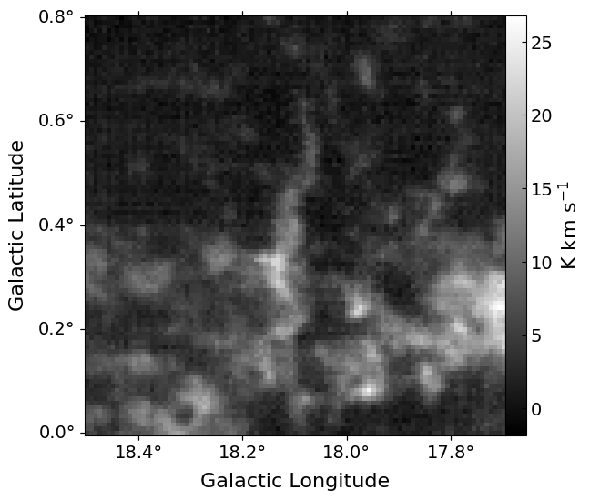

```python
save_path = 'Images/Example_Data.pdf'
Plot_and_Save_Funs.Plot_Origin_Data(clumpsObj,figsize=(8,6),fontsize=16,spacing=12*u.arcmin,save_path=save_path)
```

Plot the detection results and save the image.

```python
edges = clumpsObj.edges
print('Total number:',len(edges))
print('NO edges number:',np.where(edges==0)[0].shape[0])
```

```
Total number: 126
NO edges number: 88
```

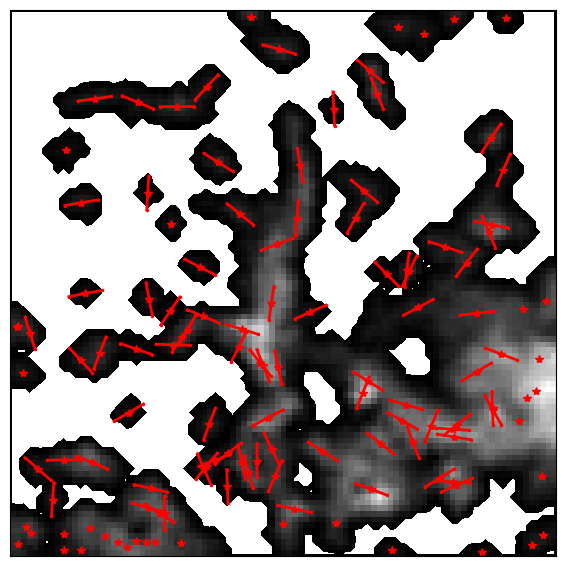

```python
save_path = 'Images/Clumps_Infor.pdf'
Plot_and_Save_Funs.Plot_Clumps_Infor(clumpsObj,figsize=(8,6),line_scale=3,save_path=save_path)
```

Get the clumps information from the clumpsObj.

```python
clump_angles = clumpsObj.angles
clump_edges = clumpsObj.edges
clump_centers = clumpsObj.centers
clump_centers_wcs = clumpsObj.centers_wcs
origin_data = clumpsObj.origin_data
regions_data = clumpsObj.regions_data
data_wcs = clumpsObj.data_wcs
connected_ids_dict = clumpsObj.connected_ids_dict
clump_coords_dict = clumpsObj.clump_coords_dict

clumps_data = np.zeros_like(origin_data)
clumps_data[regions_data>0] = origin_data[regions_data>0]
```

### The Algorithm in the PPP Space: DisPerSE

P5RMS_R5RMS:

RMS ~ 0.22

persistence threshold = 5*RMS

robustness threshold = 5*RMS

```python
# sk_file_name = '../Filaments/Data/DisPerSE/P4RMS_R4RMS.fits'
sk_file_name = '../Filaments/Data/DisPerSE/P5RMS_R5RMS.fits'
# sk_file_name = '../Filaments/Data/DisPerSE/P6RMS_R6RMS.fits'
# sk_file_name = '../Filaments/Data/DisPerSE/P8RMS_R8RMS.fits'

# print('file_name:',sk_file_name)
skeleton_data_T = fits.getdata(sk_file_name)

skeleton_data = np.zeros_like(skeleton_data_T)
skeleton_data[skeleton_data_T>0]=1

skeleton_label = measure.label(skeleton_data,connectivity=3)
skeletons_list = measure.regionprops(skeleton_label)
```

```python
figsize=(8,6)
fontsize=12
spacing=12*u.arcmin
```

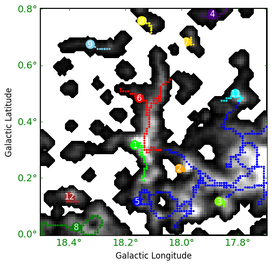

```python
fig = plt.figure(figsize=(8,6))
ax0 = fig.add_subplot(111,projection=data_wcs.celestial)


colors_T = ['lime','orange','lawngreen','indigo','blue','red','gold','green','skyblue','yellow','cyan','brown']
colors_id = 0
circle_radius = 2
for index in range(len(skeletons_list)):
    skeleton_coords = skeletons_list[index].coords[:,1:]
    if len(skeleton_coords) > 10:
        center_x = skeleton_coords[len(skeleton_coords)//2][1]-2
        center_y = skeleton_coords[len(skeleton_coords)//2][0]+1
        circle = patches.Circle((center_x, center_y), circle_radius, facecolor=colors_T[colors_id])
        ax0.add_patch(circle)
        ax0.text(center_x, center_y, "{}".format(colors_id+1), fontsize=12, color='white', va='center', ha='center')

        for i in range(len(skeleton_coords)):
            ax0.plot(skeleton_coords[i][1],skeleton_coords[i][0],color=colors_T[colors_id],marker='.',lw=3, alpha=1.0, markersize=4)
        colors_id += 1


img = clumps_data.sum(0)
vmin = np.min(img[np.where(img!=0)])
vmax = np.nanpercentile(img[np.where(img!=0)], 98.)
ax0.imshow(img,
           origin='lower',
           cmap='gray',
           interpolation='none',
           norm = colors.Normalize(vmin = vmin, vmax =  vmax))
ax0.contourf(img,
             levels = [0., .01],
             colors = 'w')
plt.rcParams['xtick.direction'] = 'in'
plt.rcParams['ytick.direction'] = 'in'
plt.rcParams['xtick.color'] = 'red'
plt.rcParams['ytick.color'] = 'red'
plt.xlabel("Galactic Longitude",fontsize=fontsize)
plt.ylabel("Galactic Latitude",fontsize=fontsize)
lon = ax0.coords[0]
lat = ax0.coords[1]
lon.set_major_formatter("d.d")
lat.set_major_formatter("d.d")
lon.set_ticks(spacing=spacing)
lat.set_ticks(spacing=spacing)

# plt.savefig('../Images/DisPerSe_LB.pdf', format='pdf', dpi=1000)
plt.show()
```

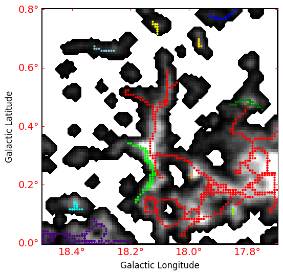

```python
sk_file_name = '../Filaments/Data/DisPerSE/P4RMS_R4RMS.fits'
# sk_file_name = '../Filaments/Data/DisPerSE/P5RMS_R5RMS.fits'
# sk_file_name = '../Filaments/Data/DisPerSE/P6RMS_R6RMS.fits'
# sk_file_name = '../Filaments/Data/DisPerSE/P8RMS_R8RMS.fits'

# print('file_name:',sk_file_name)
skeleton_data_T = fits.getdata(sk_file_name)

skeleton_data = np.zeros_like(skeleton_data_T)
skeleton_data[skeleton_data_T>0]=1

skeleton_label = measure.label(skeleton_data,connectivity=3)
skeletons_list = measure.regionprops(skeleton_label)


fig = plt.figure(figsize=(8,6))
ax0 = fig.add_subplot(111,projection=data_wcs.celestial)


colors_T = ['lime','orange','lawngreen','indigo','blue','red','gold','green','skyblue','yellow','cyan','brown',\
           'yellow','cyan','brown']
colors_id = 0
circle_radius = 2
for index in range(len(skeletons_list)):
    skeleton_coords = skeletons_list[index].coords[:,1:]
    if len(skeleton_coords) > 10:
        center_x = skeleton_coords[len(skeleton_coords)//2][1]-2
        center_y = skeleton_coords[len(skeleton_coords)//2][0]+1
        circle = patches.Circle((center_x, center_y), circle_radius, facecolor=colors_T[colors_id])
#         ax0.add_patch(circle)
#         ax0.text(center_x, center_y, "{}".format(colors_id+1), fontsize=12, color='white', va='center', ha='center')

        for i in range(len(skeleton_coords)):
            ax0.plot(skeleton_coords[i][1],skeleton_coords[i][0],color=colors_T[colors_id],marker='.',lw=3, alpha=1.0, markersize=4)
        colors_id += 1


img = clumps_data.sum(0)
vmin = np.min(img[np.where(img!=0)])
vmax = np.nanpercentile(img[np.where(img!=0)], 98.)
ax0.imshow(img,
           origin='lower',
           cmap='gray',
           interpolation='none',
           norm = colors.Normalize(vmin = vmin, vmax =  vmax))
ax0.contourf(img,
             levels = [0., .01],
             colors = 'w')
plt.rcParams['xtick.direction'] = 'in'
plt.rcParams['ytick.direction'] = 'in'
plt.rcParams['xtick.color'] = 'red'
plt.rcParams['ytick.color'] = 'red'
plt.xlabel("Galactic Longitude",fontsize=fontsize)
plt.ylabel("Galactic Latitude",fontsize=fontsize)
lon = ax0.coords[0]
lat = ax0.coords[1]
lon.set_major_formatter("d.d")
lat.set_major_formatter("d.d")
lon.set_ticks(spacing=spacing)
lat.set_ticks(spacing=spacing)

# plt.savefig('../Images/DisPerSe_LB_4RMS.pdf', format='pdf', dpi=1000)
plt.show()
```

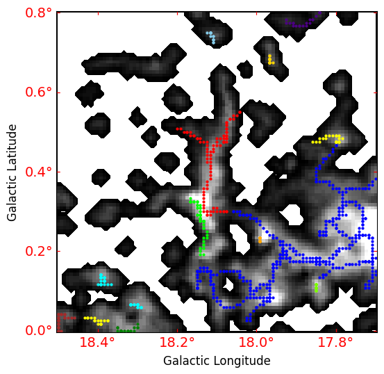

```python
# sk_file_name = '../Filaments/Data/DisPerSE/P4RMS_R4RMS.fits'
# sk_file_name = '../Filaments/Data/DisPerSE/P5RMS_R5RMS.fits'
sk_file_name = '../Filaments/Data/DisPerSE/P6RMS_R6RMS.fits'
# sk_file_name = '../Filaments/Data/DisPerSE/P8RMS_R8RMS.fits'

# print('file_name:',sk_file_name)
skeleton_data_T = fits.getdata(sk_file_name)

skeleton_data = np.zeros_like(skeleton_data_T)
skeleton_data[skeleton_data_T>0]=1

skeleton_label = measure.label(skeleton_data,connectivity=3)
skeletons_list = measure.regionprops(skeleton_label)


fig = plt.figure(figsize=(8,6))
ax0 = fig.add_subplot(111,projection=data_wcs.celestial)


colors_T = ['lime','orange','lawngreen','indigo','blue','red','gold','green','skyblue','yellow','cyan','brown',\
           'yellow','cyan','brown']
colors_id = 0
circle_radius = 2
for index in range(len(skeletons_list)):
    skeleton_coords = skeletons_list[index].coords[:,1:]
    if len(skeleton_coords) > 10:
        center_x = skeleton_coords[len(skeleton_coords)//2][1]-2
        center_y = skeleton_coords[len(skeleton_coords)//2][0]+1
        circle = patches.Circle((center_x, center_y), circle_radius, facecolor=colors_T[colors_id])
#         ax0.add_patch(circle)
#         ax0.text(center_x, center_y, "{}".format(colors_id+1), fontsize=12, color='white', va='center', ha='center')

        for i in range(len(skeleton_coords)):
            ax0.plot(skeleton_coords[i][1],skeleton_coords[i][0],color=colors_T[colors_id],marker='.',lw=3, alpha=1.0, markersize=4)
        colors_id += 1


img = clumps_data.sum(0)
vmin = np.min(img[np.where(img!=0)])
vmax = np.nanpercentile(img[np.where(img!=0)], 98.)
ax0.imshow(img,
           origin='lower',
           cmap='gray',
           interpolation='none',
           norm = colors.Normalize(vmin = vmin, vmax =  vmax))
ax0.contourf(img,
             levels = [0., .01],
             colors = 'w')
plt.rcParams['xtick.direction'] = 'in'
plt.rcParams['ytick.direction'] = 'in'
plt.rcParams['xtick.color'] = 'red'
plt.rcParams['ytick.color'] = 'red'
plt.xlabel("Galactic Longitude",fontsize=fontsize)
plt.ylabel("Galactic Latitude",fontsize=fontsize)
lon = ax0.coords[0]
lat = ax0.coords[1]
lon.set_major_formatter("d.d")
lat.set_major_formatter("d.d")
lon.set_ticks(spacing=spacing)
lat.set_ticks(spacing=spacing)

# plt.savefig('../Images/DisPerSe_LB_6RMS.pdf', format='pdf', dpi=1000)
plt.show()
```

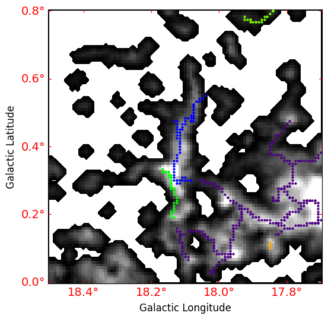

```python
# sk_file_name = '../Filaments/Data/DisPerSE/P4RMS_R4RMS.fits'
# sk_file_name = '../Filaments/Data/DisPerSE/P5RMS_R5RMS.fits'
# sk_file_name = '../Filaments/Data/DisPerSE/P6RMS_R6RMS.fits'
sk_file_name = '../Filaments/Data/DisPerSE/P8RMS_R8RMS.fits'

# print('file_name:',sk_file_name)
skeleton_data_T = fits.getdata(sk_file_name)

skeleton_data = np.zeros_like(skeleton_data_T)
skeleton_data[skeleton_data_T>0]=1

skeleton_label = measure.label(skeleton_data,connectivity=3)
skeletons_list = measure.regionprops(skeleton_label)


fig = plt.figure(figsize=(8,6))
ax0 = fig.add_subplot(111,projection=data_wcs.celestial)


colors_T = ['lime','orange','lawngreen','indigo','blue','red','gold','green','skyblue','yellow','cyan','brown',\
           'yellow','cyan','brown']
colors_id = 0
circle_radius = 2
for index in range(len(skeletons_list)):
    skeleton_coords = skeletons_list[index].coords[:,1:]
    if len(skeleton_coords) > 10:
        center_x = skeleton_coords[len(skeleton_coords)//2][1]-2
        center_y = skeleton_coords[len(skeleton_coords)//2][0]+1
        circle = patches.Circle((center_x, center_y), circle_radius, facecolor=colors_T[colors_id])
#         ax0.add_patch(circle)
#         ax0.text(center_x, center_y, "{}".format(colors_id+1), fontsize=12, color='white', va='center', ha='center')

        for i in range(len(skeleton_coords)):
            ax0.plot(skeleton_coords[i][1],skeleton_coords[i][0],color=colors_T[colors_id],marker='.',lw=3, alpha=1.0, markersize=4)
        colors_id += 1


img = clumps_data.sum(0)
vmin = np.min(img[np.where(img!=0)])
vmax = np.nanpercentile(img[np.where(img!=0)], 98.)
ax0.imshow(img,
           origin='lower',
           cmap='gray',
           interpolation='none',
           norm = colors.Normalize(vmin = vmin, vmax =  vmax))
ax0.contourf(img,
             levels = [0., .01],
             colors = 'w')
plt.rcParams['xtick.direction'] = 'in'
plt.rcParams['ytick.direction'] = 'in'
plt.rcParams['xtick.color'] = 'red'
plt.rcParams['ytick.color'] = 'red'
plt.xlabel("Galactic Longitude",fontsize=fontsize)
plt.ylabel("Galactic Latitude",fontsize=fontsize)
lon = ax0.coords[0]
lat = ax0.coords[1]
lon.set_major_formatter("d.d")
lat.set_major_formatter("d.d")
lon.set_ticks(spacing=spacing)
lat.set_ticks(spacing=spacing)

# plt.savefig('../Images/DisPerSe_LB_8RMS.pdf', format='pdf', dpi=1000)
plt.show()
```

### DisPerSE in Simulation

```python
RMS = 0.1
Threshold = 5 * RMS

parameters_FacetClumps = [RMS, Threshold, SWindow, KBins, FwhmBeam, VeloRes, SRecursionLBV]
```

```python
file_name = 'RandA_260_13CO.fits'

file_example = 'Simulation_1'
mask_name = '../Example_Files/Clump/mask_{}.fits'.format(file_example)
outcat_name = '../Example_Files/Clump/outcat_{}.csv'.format(file_example)
outcat_wcs_name = '../Example_Files/Clump/outcat_wcs_{}.csv'.format(file_example)
```

```python
clumpsObj = ClumpInfor(file_name,mask_name,outcat_name,outcat_wcs_name)

# clumpsObj.Cal_Infor_From_Mask_Or_Algorithm(mask_or_algorithm='FacetClumps',parameters=parameters_FacetClumps)
# clumpsObj.Get_Clumps_Infor(fit_flag = True)

clumpsObj.Cal_Infor_From_Mask_Or_Algorithm(mask_or_algorithm='mask')
clumpsObj.Get_Clumps_Infor(fit_flag = True)
```

```
Number: 373
Time: 0.52
```

```
Fitting Clumps Time: 8.15
```

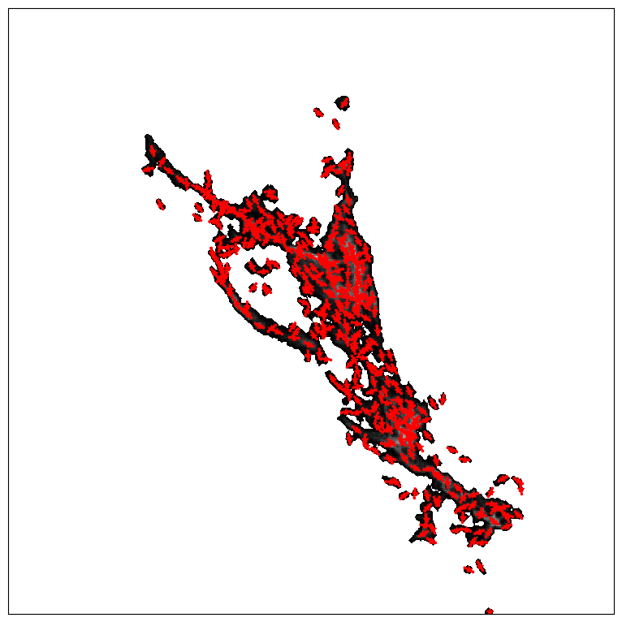

```python
save_path = 'Images/Clumps_Infor.pdf'
Plot_and_Save_Funs.Plot_Clumps_Infor(clumpsObj,figsize=(12,8),line_scale=3,save_path=None)
```

```python
clump_angles = clumpsObj.angles
clump_edges = clumpsObj.edges
clump_centers = clumpsObj.centers
clump_centers_wcs = clumpsObj.centers_wcs
origin_data = clumpsObj.origin_data
regions_data = clumpsObj.regions_data
data_wcs = clumpsObj.data_wcs
connected_ids_dict = clumpsObj.connected_ids_dict
clump_coords_dict = clumpsObj.clump_coords_dict

clumps_data = np.zeros_like(origin_data)
clumps_data[regions_data>0] = origin_data[regions_data>0]
```

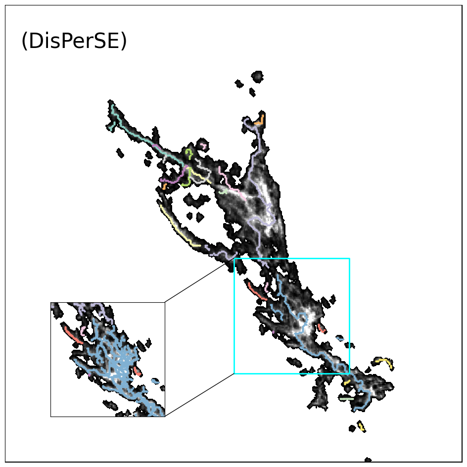

```python
sk_file_name = 'P10RMS_R10RMS.fits'

# print('file_name:',sk_file_name)
skeleton_data_T = fits.getdata(sk_file_name)

skeleton_data = np.zeros_like(skeleton_data_T)
skeleton_data[skeleton_data_T>0]=1

skeleton_label = measure.label(skeleton_data,connectivity=3)
skeletons_list = measure.regionprops(skeleton_label)

fontsize = 30
fig = plt.figure(figsize=(14,12))
ax0 = fig.add_subplot(111)#,projection=data_wcs.celestial)

ax0.text(13,362,r'({})'.format('DisPerSE'),color='black',fontsize=fontsize)

colors_T = plt.cm.Set3(np.linspace(0, 1, 30))
# colors_T = colors_T[::-1]
colors_id = 0
for index in range(len(skeletons_list)):
    skeleton_coords = skeletons_list[index].coords[:,1:]

    if len(skeleton_coords) > 10:
        G_longest_skeleton, T_longest_skeleton = FCFA.Graph_Infor_Connected(skeleton_coords)
        max_path, max_edges = FCFA.Get_Max_Path_Weight(T_longest_skeleton)
        skeleton_coords = skeleton_coords[max_path]
        for i in range(len(skeleton_coords)):
            ax0.plot(skeleton_coords[i][1],skeleton_coords[i][0],color=colors_T[colors_id],marker='.',lw=3, alpha=1.0, markersize=4)
        colors_id += 1


img = clumps_data.sum(0)
vmin = np.min(img[np.where(img!=0)])
vmax = np.nanpercentile(img[np.where(img!=0)], 98.)
ax0.imshow(img,
           origin='lower',
           cmap='gray',
           interpolation='none',
           norm = colors.Normalize(vmin = vmin, vmax =  vmax))
ax0.contourf(img,
             levels = [0., .01],
             colors = 'w')

linked = 'left'
xlim_left, xlim_right = 180+20,281+20
ylim_bottom, ylim_top = 97-20,198-20
axins = ax0.inset_axes((0.1, 0.1, 0.25, 0.25))
axins.set_xlim(xlim_left, xlim_right)
axins.set_ylim(ylim_bottom, ylim_top)

ax0.plot([xlim_left,xlim_right,xlim_right,xlim_left,xlim_left],
            [ylim_bottom,ylim_bottom,ylim_top,ylim_top,ylim_bottom],linewidth=2,color = 'cyan')
if linked == 'bottom':
    xyA_1, xyB_1 = (xlim_left,ylim_top), (xlim_left,ylim_bottom)
    xyA_2, xyB_2 = (xlim_right,ylim_top), (xlim_right,ylim_bottom)
elif  linked == 'top':
    xyA_1, xyB_1 = (xlim_left,ylim_bottom), (xlim_left,ylim_top)
    xyA_2, xyB_2 = (xlim_right,ylim_bottom), (xlim_right,ylim_top)
elif  linked == 'left':
    xyA_1, xyB_1 = (xlim_right,ylim_top), (xlim_left,ylim_top)
    xyA_2, xyB_2 = (xlim_right,ylim_bottom), (xlim_left,ylim_bottom)
elif  linked == 'right':
    xyA_1, xyB_1 = (xlim_left,ylim_top), (xlim_right,ylim_top)
    xyA_2, xyB_2 = (xlim_left,ylim_bottom), (xlim_right,ylim_bottom)

con = ConnectionPatch(xyA=xyA_1,xyB=xyB_1,coordsA="data",
                      coordsB="data",axesA=axins,axesB=ax0)
axins.add_artist(con)
con = ConnectionPatch(xyA=xyA_2,xyB=xyB_2,coordsA="data",
                      coordsB="data",axesA=axins,axesB=ax0)
axins.add_artist(con)
axins.set_xticks([])
axins.set_yticks([])

colors_id = 0
for index in range(len(skeletons_list)):
    skeleton_coords = skeletons_list[index].coords[:,1:]

    if len(skeleton_coords) > 10:
#         G_longest_skeleton, T_longest_skeleton = FCFA.Graph_Infor_Connected(skeleton_coords)
#         max_path, max_edges = FCFA.Get_Max_Path_Weight(T_longest_skeleton)
#         skeleton_coords = skeleton_coords[max_path]
        for i in range(len(skeleton_coords)):
            axins.plot(skeleton_coords[i][1],skeleton_coords[i][0],color=colors_T[colors_id],marker='.',lw=3, alpha=1.0, markersize=4)
        colors_id += 1


img = clumps_data.sum(0)
img_color = img[xlim_left:xlim_right,ylim_bottom:ylim_top]
vmin = np.min(img_color[np.where(img_color!=0)])
vmax = np.nanpercentile(img_color[np.where(img_color!=0)], 98.)
axins.imshow(img,
           origin='lower',
           cmap='gray',
           interpolation='none',
           norm = colors.Normalize(vmin = vmin, vmax =  vmax))
axins.contourf(img,
             levels = [0., .01],
             colors = 'w')

plt.rcParams['xtick.direction'] = 'in'
plt.rcParams['ytick.direction'] = 'in'
plt.rcParams['xtick.color'] = 'red'
plt.rcParams['ytick.color'] = 'red'
# plt.xlabel("Galactic Longitude",fontsize=fontsize)
# plt.ylabel("Galactic Latitude",fontsize=fontsize)
plt.xticks([]),plt.yticks([])

# plt.savefig('../Images/HD_DisPerSE.pdf', format='pdf', dpi=1000)
plt.show()
```

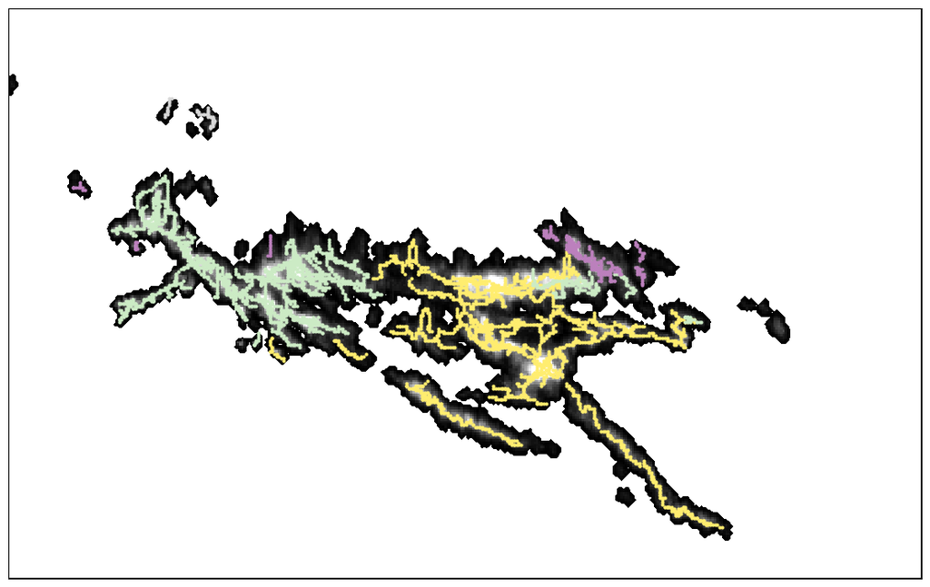

```python
fig = plt.figure(figsize=(14,12))
ax0 = fig.add_subplot(111)#,projection=data_wcs.celestial)

# ax0.text(13,362,r'({})'.format('DisPerSE'),color='black',fontsize=fontsize)

colors_T = plt.cm.Set3(np.linspace(0, 1, len(skeletons_list)))
colors_T = colors_T[::-1]

colors_id = 0
circle_radius = 2
for index in range(len(skeletons_list)):
    skeleton_coords = skeletons_list[index].coords[:,:2]
    if len(skeleton_coords) > 10:
        for i in range(len(skeleton_coords)):
            ax0.plot(skeleton_coords[i][1],skeleton_coords[i][0],color=colors_T[colors_id],marker='.',lw=3, alpha=1.0, markersize=4)
        colors_id += 1


img = clumps_data.sum(2)
vmin = np.min(img[np.where(img!=0)])
vmax = np.nanpercentile(img[np.where(img!=0)], 98.)
ax0.imshow(img,
           origin='lower',
           cmap='gray',
           interpolation='none',
           norm = colors.Normalize(vmin = vmin, vmax =  vmax))
ax0.contourf(img,
             levels = [0., .01],
             colors = 'w')
plt.rcParams['xtick.direction'] = 'in'
plt.rcParams['ytick.direction'] = 'in'
plt.rcParams['xtick.color'] = 'red'
plt.rcParams['ytick.color'] = 'red'
# plt.xlabel("Galactic Longitude",fontsize=fontsize)
# plt.ylabel("Galactic Latitude",fontsize=fontsize)
plt.xticks([]),plt.yticks([])

# plt.savefig('../Images/HD_DisPerSE_LV.pdf', format='pdf', dpi=1000)
plt.show()
```